# fMRI_Cont_LTM

Basic Goal: Reconstruct color memory for encoded objects during an irrelevant task where subjects are not explicitly retrieving that object's color. Compare behavioral memory performance with inverted encoding results.

The current idea is to split the fMRI experiment into two sessions.

One for the anatomical scan, functional localizer, and encoding model. The other for the actual color memory task.

Here is the design that was initially proposed. I originally thought this would have to be two two-hour sessions, but perhaps it may be shortened to two 1.5-hour sessions (in which the second session also has an added 30 minutes for testing color memory outside the scanner).

Remember that this experiment has no bias in color sampling! I often accidentally get this experiment and the statistical regularities experiment confused.

# Design

## Session 1

### 1. Anatomical Scan & Functional Localizers

- Retinotopic mapping
- Color contrast (black & white vs. colored)
- LOC localizer

**Total Time: ~30 minutes**

### 2. Train Encoder

- 2-back letter task at fixation
- 1.5 s duration, 3-6 s ISI
- 9 channels

*Total Trials: ~600*

**Total Time: ~60 minutes, or as much time as is remaining assuming a 1.5 hour session**

*Question: Do I need to make total trials consistent for each subject or is it fine to vary somewhat depending on time? If one person has more time in the scanner than another, should I run more encoding trials or is it more important to keep num of trials consistent?*

## Session 2

### 1. Study Phase

- 324 objects + (24 * 2) trials of repeats
- 1 s display and 1 s ITI
- Jittered (+/- 10 deg) according to means of 9 predetermined divisions on color wheel
- Repeat detection task: if same object is presented twice in a row, press the spacebar (occurs 24 times)

**Total Time: 12.5 minutes**

*I am equally dividing the color wheel into 18 parts, with each region encompassing 20 degrees. Every other division contains a color region that will never be shown for any object. The other 9 color regions will be equally sampled for object colors, with random jitter of +- 10 degrees.*

### 2. Grayscale Judgments

- 324 objects (doesn't include the repeats)
- 1 s display
- 8 - 12 s ISI (random amount of ms between 8000 and 12000 ms)
- Respond if small (can hold in hand) or large

**Total Time: ~1 hour**

*Is this an okay irrelevant task for the inverted encoding model? One thing I noticed is that a disproportionate amount of the objects are small enough to hold in the hand. Would this mess anything up?*

*I have it so that the grayscale objects are presented sequentially without ever stopping in case the participant fails to input a response. There is no feedback for responses either. This is the correct way to do it, I think?*

### 3. Test Phase (outside the scanner)

- Continuous color report (for the 324)

**Total Time: 25 - 30 minutes**

*Do you agree that the study phase should be inside the scanner and the test phase should be outside the scanner?*

# Pilot (Behavioral) Testing

To make sure that participants could remember object colors throughout the long delay imposed by the size judgment task, we ran participants in a behavioral version of the above design.

I ran 3 subjects in this version. Here are their below histograms (0 means they gave exactly the correct color response).

```
subj 1
did not converge using standard mixture model
```

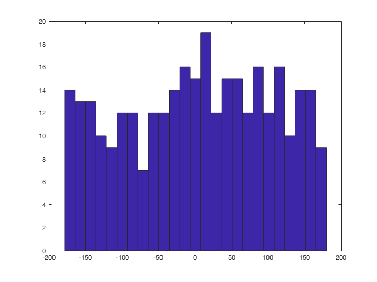

```matlab
cd '/Users/scotti.5/Dropbox/Shared Lab Folder/Experiments/Contextual_LTM/Contextual bias in LTM Exp_V7'
disp('subj 1');
openfig('subj1_hist.fig');
disp('did not converge using standard mixture model');
```

```
subj 2
```

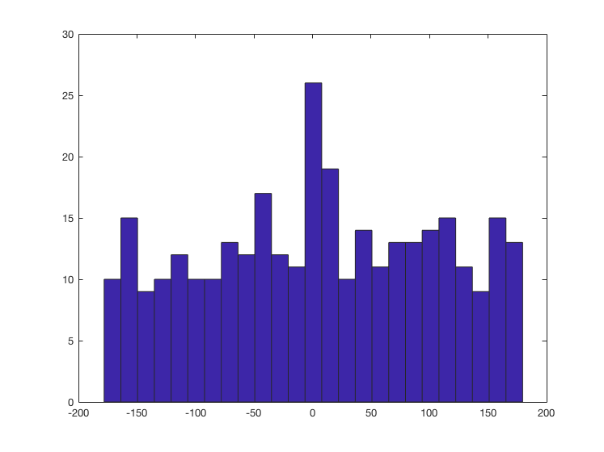

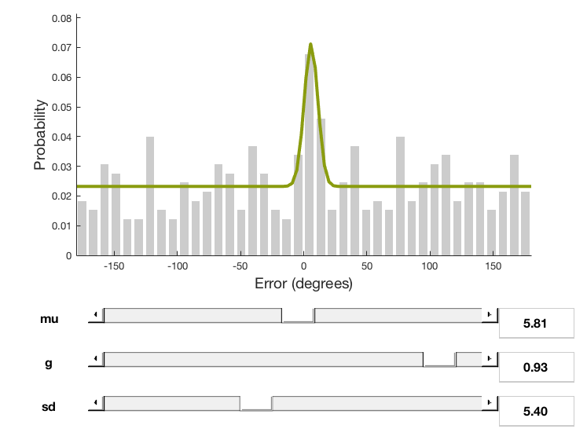

```matlab
disp('subj 2');
openfig('subj2_smm.fig');
openfig('subj2_hist.fig');
```

```
subj 3
```

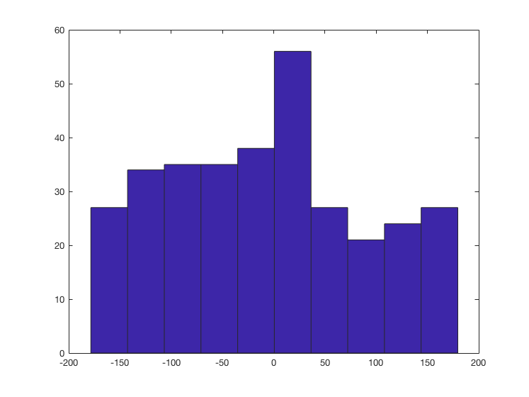

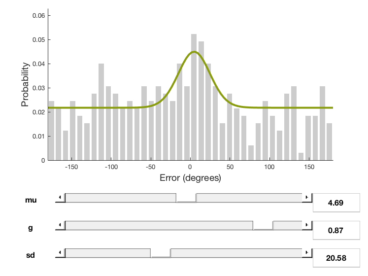

```matlab
disp('subj 3');
openfig('subj3_smm.fig');
openfig('subj3_hist.fig');
```

## Thoughts

Subjects did not perform as well as I was hoping. Their high guess rate and noisy responses likely prevent us from following through with the proposed design in the scanner.

**Therefore, I ran one more subject using a modified design.** I cut the amount of objects required to memorize from 324 to 216. These 216 objects were presented not once but twice throughout the entire experiment. The idea was that less objects, presented twice, might improve performance enough to withstand the size judgment task.

Here is that subject's results:

```
subj 4
```

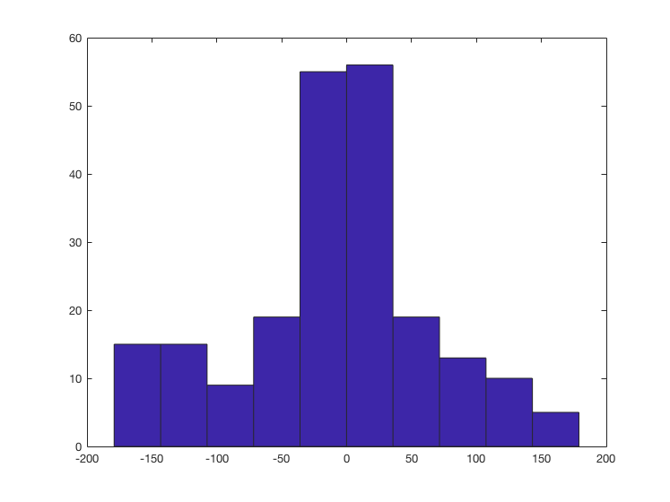

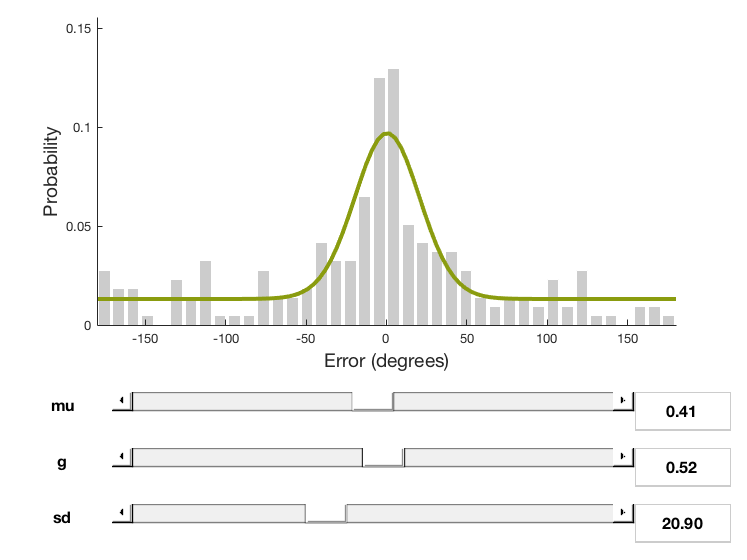

```matlab
disp('subj 4');
openfig('subj4_smm.fig');
openfig('subj4_hist.fig');
```

# Thoughts

This data looks much more promising! However, it is unclear whether the better performance is due to the subject having amazing memory, the reduced overall amount of objects memorized, or because objects were displayed twice during the learning phase. It is also important that we figure out whether objects may only need to be presented once because of the idea that we may later get into biased color sampling.

**I would like to run some more pilots in order to figure out this question. Perhaps one more pilot in the same design as subject 4, and one or two pilots in an experiment where the objects are only displayed once (but the amount of objects is still reduced to 216 instead of 324).**

**Also I have some questions about the way that I randomized the presentation of these twice-repeated objects.** How I did it is by taking the first half of the experiment (sans repeat detection objects which are never tested) and randomizing these trials and playing them all again for the second half. This means that all objects are being repeated in the 2nd half of the experiment. Should I be instead randomizing the objects in a different manner, where all objects repeat twice but when they repeat twice is completely random? Should I be testing repeat detection items now that all objects are repeated twice? Should I discard back-to-back repeat-detection objects and simply change the task to pressing spacebar whenever an object repeats (assuming I randomized more fully isntead of constrained to the second half). I could see pros and cons to both. In the current way, no object is *too* advantaged, for instance if we more fully randomized then an object could be presented twice near the beginning of the experiment which could deter performance.